# ARIMA

Bongus

2019 5 7

# ARIMA

## 시계열의 정상성

1. 자기상관
- 상관관계(Correation): 두 변수, 두 데이터 사이의 관계를 의미.
- 자기상관(AutoCorreation): 하나의 시계열 안에서 한 시점과 다른 시점, 즉 시간의 흐름 안에서 다른 두 시점 사이의 상관관계를 의미한다. 시간이 흐를수록 과거의 데이터가 현재의 데이터에 얼마나 영향을 미치는지를 의미하는 수치.
2. 시계열의 정상성(Stationarity): ARIMA는 정상인 시계열을 가지고 하는 방법.
- 정상: 시계열의 결합확률분포가 시간에 따라 변하지 않는다.
- Fx(x1, … ,x10) = Fx(x11, … ,x20)
- 시계열 역시 어떤 분포에서 발생해서 이벤트가 된 데이터.
- 시계열이 흘러가며 발생하는 이벤트의 분포가 시간에 따라 바뀌지 않는 것.
- 약한정상(일반적 정산의 정의): 시계열의 평균, 분산이 일정하고 자기상관함수(ACF)는 시간이 아닌 시차의 함수
- 평균이 일정하다는 것은 시계열내(증가 또는 감소하는) 뚜렷한 트랜드가 없다. 변동은 있지만 전체 트렌드에서 봤을 때 평균이 일정하다는 의미.
- 분산이 일정하다는 것은 시계열변화의 폭이 일정하다. 변동 폭이 일정.
- 시계열 내 두 데이터간에 상관관계는 시간이 아닌 시차(lag)에 따라 결정. 얼만큼 떨어져 있는가에 따라 결정된다는 것.
3. 시계열의 정상성
- 정상시계열: 움직임의 폭이 얼정, 유의한 트랜드가 없다.
- 비정상시계열: 뚜렷한 트랜드가 존재하며 분산도 정상시계열에 비해 그 폭이 크다.
4. 정상시계열 예시: 백색소음(White noise), 모형으로 설명을 못한 부분이 백색소음이라면 모형으로 어느정도 설명을 다 했다고 판단. 즉, 백색소음은 설명이 안되는 부분이라고 생각하면 된다.
- 특징
- 평균 = 0: 시간에 따라 변하지 않음.
- 분산 = constant: 시간에 따라 변하지 않음
- 데이터들이 서로 독립 => 데이터들 간에 서로 관계가 없음. 영향이 없음. 자기상관x

```r
library(forecast)
library(tseries)

set.seed(12134)
white_noise <- rnorm(1000) # 1000개 랜덤추출. 평균0, 분산1 (대체적으로)
mean(white_noise)
```

```
## [1] -0.03060437
```

```r
var(white_noise)
```

```
## [1] 0.9778764
```

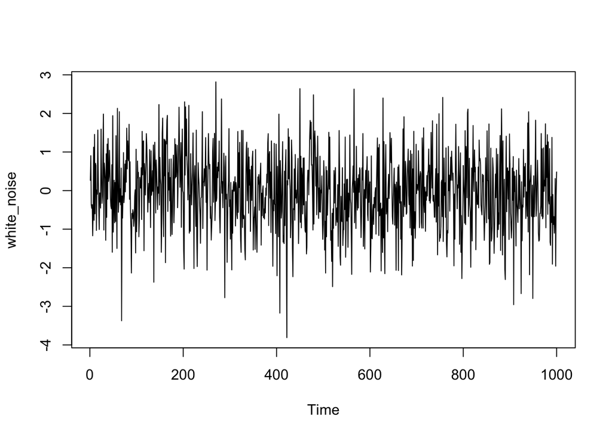

```r
ts.plot(white_noise)
```

5. 비정상시계: Random walk($y_t = yt-1 + e_t (e_t는 백색소음)$)
- 직전 시계열로부터 증가감소가 되는 것을 표현.
- Random walk는 금융데이터를 분석할 때 많이 사용된다.
- 평균 = constant: 시간에 따라 변하지 않음.
- 분산 = t$\sigma^2$: 시간에 따라 증가.

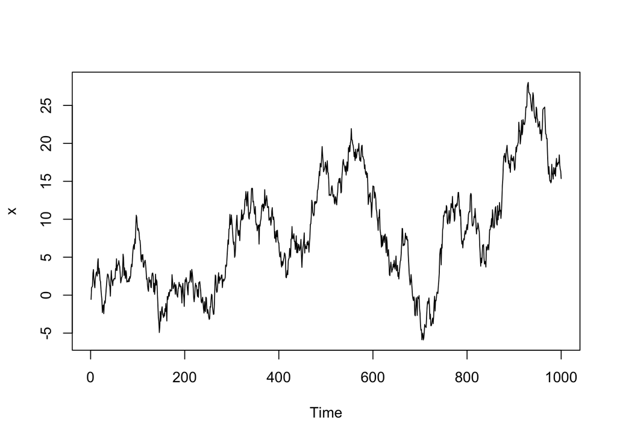

```r
set.seed(123)
x <- rnorm(1)
w <- rnorm(1000)
for(t in 2:1000){ x[t] <- x[t-1] + w[t]}
ts.plot(x)
```

6. ARIMA
- 비정상 시계열을 정상 시계열로 바꾸는 작업이 필요하다.
- ARIMA 모델은 정상 시계열을 가지고 모델링할 수 있다.
- 차분(diff) - 앞의 데이터와 지금 데이터의 차이를 구하는 것.
- 차분을 통해 트렌드를 제거할 수 있다. *log 변환 - log를 통해 분산을 안정화 시킬 수 있다.

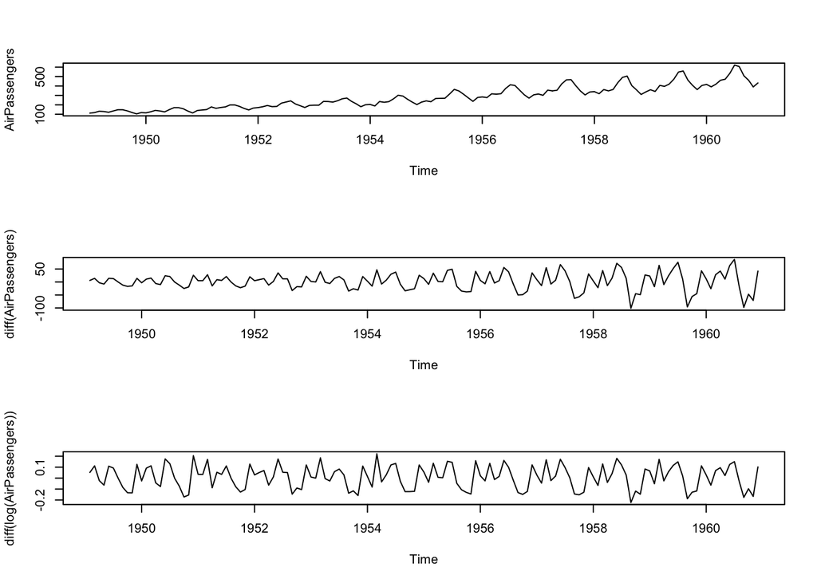

```r
# diff(차분: 시계열의 정상화)
par(mfrow=c(3,1))
plot(AirPassengers)
plot(diff(AirPassengers))
plot(diff(log(AirPassengers)))
```

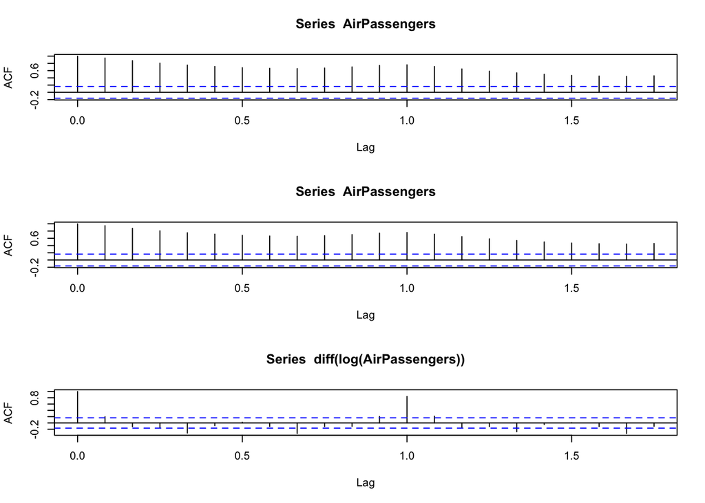

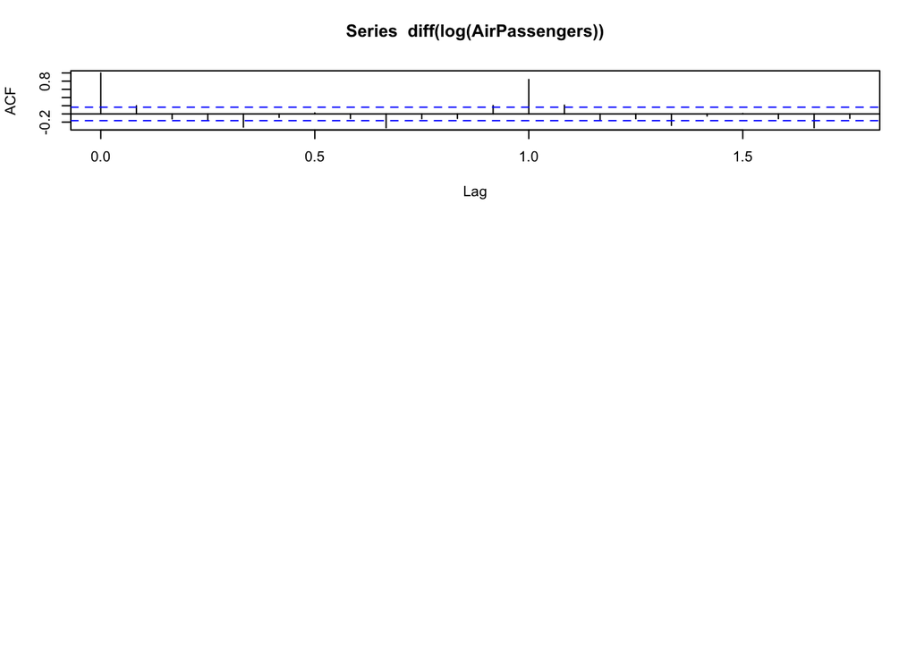

```r
plot(acf(AirPassengers))
plot(acf(diff(log(AirPassengers))))
```

7. 정상시계열 판단: ACF - 시계열의 자기상관 계산하는 함수

## ARIMA 모형(AutoRegressiv Intergrated Moving Average)

### 자기상관모형, 이동평균모형의 통합, Intergated mean diff

### 과거데이터, 백색소음 데이터로 설명 가능.

1. ARIMA모형은 다음 중 하나
- AR(p) = 자기상관모형
- MA(q) = 이동평균모형
- AR(p) + MA(q) = ARMA
- AR(p) + MA(q) + differencing(차분) = ARIMA
2. ARIMA모형은 시계열을 보다 수학적으로 표현하는 것이다. 이론적 가정이 포함되어있다.
- 평균/뷴산/상관관계 등에 대한 조건들을 만족하여야 설명가능한 모형으로서 의미
- if 정상성이 아닌경우, 평균/뷴산/Dependence구조 등 시계열분포에 대한 가정이 정상성임(차분을 통해 정상시계열로 변환)
- 정상성을 만족하는 시계열을 ARMA로 fitting했을때 모형의 정확성이 확보
- ARMA Process는 정상시계열을 가정하고 있는 시계열분포(Population).
- 따라서 시계열데이터는 ARMA라라는 분포에서 추출된 하나의 샘플(sample)이다.
- sample을 이용, 분포(ARMA)를 추정하여 데이터를 해석.

### AR

3. AR(p)모형 (자기상관모형)
- 시계열데이터의 현재는 과거의 데이터를 통해 설명이 가능하다.
- 현재 시계열은 과거 시계열의 조합으로 설명이 가능한 모형이라는 가정.
- p는 현재를 기준으로 과거 어디까지 살펴볼 것인지에 대한 기준.
- p = 1이면 직전 과거치를 통해 현재 시계열데이터를 살펴보겠다는 것.
- 그래서 p를 결정하는 것 역시 중요. 좋은 예측을 위한 노가다?
4. ex. AR(1): $X+t = \alpha X_{t-1} + w_t with -1 < \alpha < 1$
- $\alpha X_{t-1}$ 외에 나머지 부분은 $w_t$라고 가정.
- $\alpha$가 어떤 것인지 찾는 것을 ARIMA모형을 만들 떄 계산하게 된다.
- AR(1)모형은 쉽게만들 수 있다.

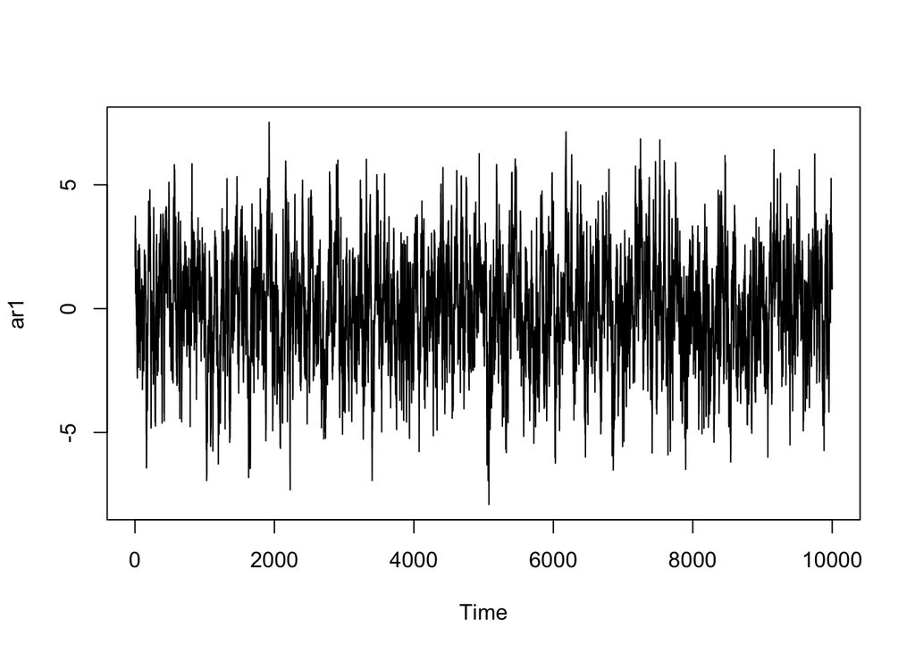

```r
library(forecast)
library(tseries)
# AR(1), alpha = 0.9라고 가정
ar1 <- arima.sim(n = 10000, list(ar=c(0.9)))
ts.plot(ar1)
```

- AR모형의 의미: 어떤 데이터를 그 데이터의 과거를 변수로해서 설명하는 식.
- 회귀모형: y를 x라는 변수로 설명하는 것. x, y의 관계를 이용해 y를 설명.
- 자기상관모형(AR): 관심있는 시점의 x의 시계열 데이터를 다른 시점의 데이터와 관계를 이용해 찾는것. 과거의 데이터가 현재에 영향을 미치는 자기상관관계를 이용하는 것.
- 회귀, 자기상관모형 모두 모형으로 설명된 나머지 잔차는 white noise를 따른다고 가정.
- 회귀모형 및 자기상관모형은 데이터를 설명하는 모형(설명변수 또는 과거데이터를 이용)이며 마지막 오차항($\epsilon, Z$)는 white noise
5. AR(p)모형에서 파라미터 $\phi는 -1 < \phi < 1$이어야 한다. 1이거나 1보다 클 경우 랜덤워크거나 무한대로 발산하게 된다.
6. 만약 $\phi가$ $|\phi| < 1$이 아닌 경우에는 비정상시계열이기 때문에 차분을 통해 정상시계열화 시켜 계산을 하게 된다. $\phi가$ 1보다 큰 경우를 explosive라고 하며 비정상시계열이다. $\phi가$ 1보다 크면 시계열은 급격하게 증가하는 추세를 보인다.
7. $Phi$ 경우에 따른 예시: Random-walk, Exprosive

[figure not shown]

```r
# AR phi 경우의 수: Explosive, Random walk
eps <- rnorm(1000)
eps2 <- rnorm(1000)
y <- eps
x <- eps2
for(t in 2:1000) {
  y[t] <- y[t-1] + eps[t] # random walk-non stationary
  x[t] <- 1.05*x[t-1] + eps2[t] # explosive
}

par(mfrow=c(2,2))
plot(y[1:40], type="l", main = "a = 1")
plot(x[1:40], type="l", main = "a = 1.5")
plot(y, type="l", main = "a = 1")
plot(x, type="l", main = "a = 1.5")
```

8. Unit Root Test(ADF TEST: adf.test in tserise packages) - 종류가 많음.
- 시계열이 정상인지를 확인하기 위한 테스트: 시계열이 단위근을 가지면 - 비정상
- 단위근검정: p-value가 낮아서 가성을 기각하면 단위근이 비존재 - 시게열은 정상
- $\phi$가 1보다 작은지를 검정
- $\phi$가 1인 경우 단위근을 가진다고 말하며 AR(1)에서는 랜덤워크가 된다.
- $\phi$가 1보다 작은 경우, 이 시계열은 정상시계열
- $\phi$가 1보다 큰 경우 explosive라고 하며 비정상 시계열
- $\phi$가 1인지, 1보다 작은지를 검정. 만약 $\phi$가 1보다 크면 시계열은 급격하게 증가하는 추세를 보이므로 비정상시계열
9. 단위근 검정 예시

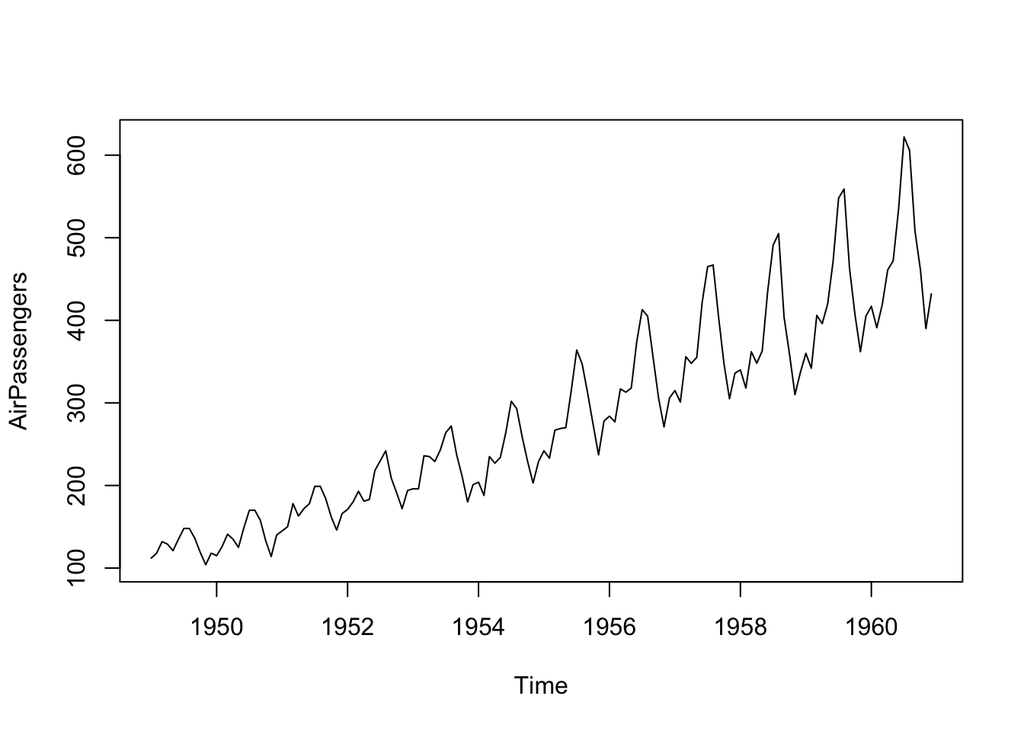

```r
# 가설: 이 시계열은 unit root를 가지고 있다. 즉, 비정상시계열이다.
# 기각하면, 정상시게열이라고 할 수 있다.
plot(AirPassengers) # 정상? 추세가 보이는데?
```

```r
adf.test(AirPassengers) # 근데 왜 단위근이 없다고 나올까.
```

```
##
##  Augmented Dickey-Fuller Test
##
## data:  AirPassengers
## Dickey-Fuller = -7.3186, Lag order = 5, p-value = 0.01
## alternative hypothesis: stationary
```

```r
# adf.test가 기본적으로 트렌드를 없앤 다음에 테스트를 하는걸로 설정되어있다.
```

10. 실제 분석에서는 ARIMA모형에 들어가기전에 미리 트렌드와 계절성에 대한 변동성을 제거해서 시계열은 안정시계열로 만든 후 분석을 하는 경우가 많다.

### ARIMA 모델링: ARIMA모델은 어떻게 만들까?

1. ARIMA 모델은 3개의 파라미터(p, q, d)를 추정하는 것
- AR(p)
- MA(q)
- differencing(d)
- = AR intergated MA
2. 먼저 차분(d)를 적용(d번 차분 후 정상으로 변환) -> ARIMA에서 I가 빠짐.
3. 정상시계열로 변환 후 ARMA모형을 적합하기위해 acf, pacf를 적용, p, q를 찾음
- ARMA는 정상인 시계열로 변환 후 모형을 적합시켜야 한다.
4. AR(p)를 위해서 pacf를 분석 => p 결정(몇 개의 AR term이 들어가는가)
- PACF 편자기상관함수
- 한개 떨어진 데이터부터 시작. 따라서 ACF의 하나 떨어진 값과 동일한 값.
- 두개 떨어졌을 때부터 달라짐. 현재 시점과 영향력을 주는 시점의 변수 사이의 값들은 무시.
- 파란색 점선 안쪽이면 자기상관이 없다고 보면 된다.
5. MA(q)를 위해 acf를 분석 => q 결정(몇 개의 MA term이 들어가는가)
- ACF 자기상관함수
- 자기상관을 의미.
- 한 칸이 하나 떨어져있는 데이터 포인트이다. 0은 자기자신과 상관계수.
- 파란색 점선 안쪽이면 자기상관이 없다고 보면 된다.

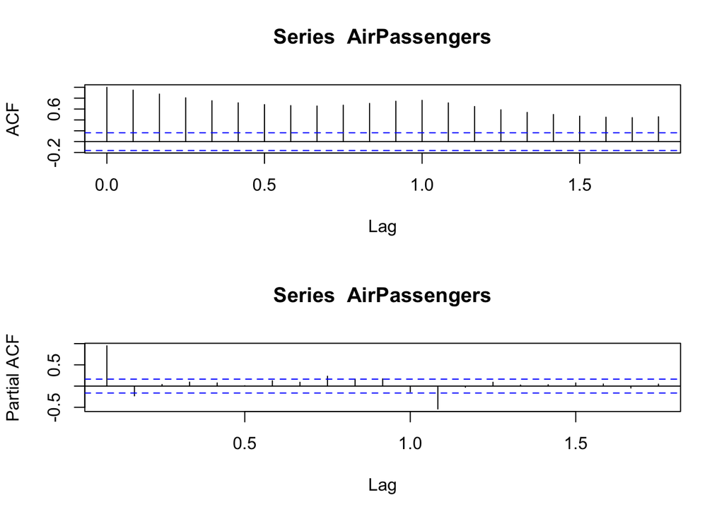

```r
library(forecast)
library(tseries)
# ACF, PACF
par(mfrow=c(2,1))
acf(AirPassengers)
pacf(AirPassengers)
```

6. White Noise
- ACF는 lag = 0 에서만 1, 그외에는 0
- PACF는 모든 lag에서 0
7. Random Walk
- ACF는 모든 lag에서 유의하게 0보다 큼.
- PACF는 lag=1에서 0보다 크고 그 외에서는 0
- 직전 데이터와는 연관이 있지만, 2개 이상 떨어진 데이터와는 관계가 없다.
8. 차분 Random Walk => 백색소음
- ACF는 lag = 0에서만 1, 그 외에는 0
- PACF는 모든 lag에서 0
- 시계열에 따라서 차분의 횟수에 차이가 있다. 적절한 횟수를 찾는게 중요.
9. if AR(1): p = 1, $\alpha = 0.9$, q = 0
- AR(p): PACF는 p시점 이후 급격히 감소 => 그 시점이 p
- ACF는 점진적으로 감소
10. MA(1): q = 1, $\theta = 0.8$, p = 0
- ACF는 q시점 이후 급격히 감소 => 그 시점이 q
- PACF는 점진적으로 감소
11. 차분을 몇번 하는가? => 단위근검정
12. 뚜렷한 정답이 있는게 아니고 노가다 작업이 필요. R에서는 auto.arima(forecast packages) or arima를 통해 최적의 arima를모델을 찾을 수 있다.
- arima function은 p, q, d를 알고 있을때 사용하는 함수
- auto.arima는 p, q, d를 모를 때 사용.
13. AIC, AICC, BIC: 모델의 설명력에 대한 지표
- AIC
- AICC: ARIMA 기준
- BIC

```r
# ARIMA 사용
auto.arima(AirPassengers)
```

```
## Series: AirPassengers
## ARIMA(2,1,1)(0,1,0)[12]
##
## Coefficients:
##          ar1     ar2      ma1
##       0.5960  0.2143  -0.9819
## s.e.  0.0888  0.0880   0.0292
##
## sigma^2 estimated as 132.3:  log likelihood=-504.92
## AIC=1017.85   AICc=1018.17   BIC=1029.35
```

```r
auto.arima(AirPassengers, trace = T) # auto.arima가 어떻게 최적의 값을 찾아가는지 확인 가능. AICC기준. AICC가 가장 낮은 값.
```

```
##
##  ARIMA(2,1,2)(1,1,1)[12]                    : Inf
##  ARIMA(0,1,0)(0,1,0)[12]                    : 1031.539
##  ARIMA(1,1,0)(1,1,0)[12]                    : 1020.582
##  ARIMA(0,1,1)(0,1,1)[12]                    : 1021.192
##  ARIMA(1,1,0)(0,1,0)[12]                    : 1020.488
##  ARIMA(1,1,0)(0,1,1)[12]                    : 1021.103
##  ARIMA(1,1,0)(1,1,1)[12]                    : Inf
##  ARIMA(2,1,0)(0,1,0)[12]                    : 1022.583
##  ARIMA(1,1,1)(0,1,0)[12]                    : 1022.583
##  ARIMA(0,1,1)(0,1,0)[12]                    : 1020.733
##  ARIMA(2,1,1)(0,1,0)[12]                    : 1018.165
##  ARIMA(2,1,1)(1,1,0)[12]                    : 1018.395
##  ARIMA(2,1,1)(0,1,1)[12]                    : 1018.84
##  ARIMA(2,1,1)(1,1,1)[12]                    : Inf
##  ARIMA(3,1,1)(0,1,0)[12]                    : 1019.565
##  ARIMA(2,1,2)(0,1,0)[12]                    : 1019.771
##  ARIMA(1,1,2)(0,1,0)[12]                    : 1024.478
##  ARIMA(3,1,0)(0,1,0)[12]                    : 1023.984
##  ARIMA(3,1,2)(0,1,0)[12]                    : Inf
##
##  Best model: ARIMA(2,1,1)(0,1,0)[12]
```

```
## Series: AirPassengers
## ARIMA(2,1,1)(0,1,0)[12]
##
## Coefficients:
##          ar1     ar2      ma1
##       0.5960  0.2143  -0.9819
## s.e.  0.0888  0.0880   0.0292
##
## sigma^2 estimated as 132.3:  log likelihood=-504.92
## AIC=1017.85   AICc=1018.17   BIC=1029.35
```

```r
auto.arima(diff(AirPassengers)) # d  = 0, 이미 차분이 된 상태이기 때문
```

```
## Series: diff(AirPassengers)
## ARIMA(2,0,1)(0,1,0)[12]
##
## Coefficients:
##          ar1     ar2      ma1
##       0.5960  0.2143  -0.9819
## s.e.  0.0888  0.0880   0.0292
##
## sigma^2 estimated as 132.3:  log likelihood=-504.92
## AIC=1017.85   AICc=1018.17   BIC=1029.35
```

```r
arima(AirPassengers, c(2,1,1), seasonal = list(order=c(0,1,1), period=12))
```

```
##
## Call:
## arima(x = AirPassengers, order = c(2, 1, 1), seasonal = list(order = c(0, 1,
##     1), period = 12))
##
## Coefficients:
##          ar1     ar2      ma1     sma1
##       0.6031  0.1998  -0.9773  -0.1065
## s.e.  0.0898  0.0898   0.0294   0.0864
##
## sigma^2 estimated as 127.7:  log likelihood = -504.18,  aic = 1018.36
```

### ARIMA Forecasting

1. p, q, d가 얼마인지 acf, pacf, unit root test를 통해 찾을 수 있다.
2. auto.arima함수는 p, q, d를 자동으로 찾아주는 함수.
3. auto.arima & forecast 함수를 이용. 10년 월별에측
4. auto.arima는 기본적으로 계절적 ARIMA를 가정해서 사용.

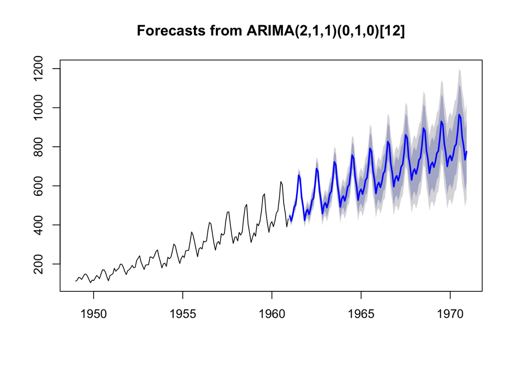

```r
library(forecast)
library(tseries)
fit <- auto.arima(AirPassengers)
arima_forecast <- forecast(fit, h=10*12)
plot(arima_forecast)
```

```r
attributes(arima_forecast) # arima_forecast에 저장된 요소 확인
```

```
## $names
##  [1] "method"    "model"     "level"     "mean"      "lower"
##  [6] "upper"     "x"         "series"    "fitted"    "residuals"
##
## $class
## [1] "forecast"
```

```r
arima_forecast$mean # 예측치
```

```
##           Jan      Feb      Mar      Apr      May      Jun      Jul
## 1961 445.6349 420.3950 449.1983 491.8399 503.3944 566.8624 654.2601
## 1962 479.2908 454.1768 483.0869 525.8192 537.4506 600.9838 688.4369
## 1963 513.6620 488.5655 517.4905 560.2354 571.8776 635.4199 722.8807
## 1964 548.1329 523.0388 551.9659 594.7126 606.3562 669.8998 757.3617
## 1965 582.6176 557.5239 586.4513 629.1982 640.8420 704.3858 791.8478
## 1966 617.1042 592.0106 620.9380 663.6849 675.3288 738.8726 826.3347
## 1967 651.5912 626.4975 655.4249 698.1719 709.8158 773.3596 860.8216
## 1968 686.0781 660.9845 689.9119 732.6588 744.3027 807.8465 895.3086
## 1969 720.5651 695.4715 724.3989 767.1458 778.7897 842.3335 929.7956
## 1970 755.0521 729.9584 758.8859 801.6328 813.2767 876.8205 964.2825
##           Aug      Sep      Oct      Nov      Dec
## 1961 638.5974 540.8837 494.1266 423.3327 465.5075
## 1962 672.8212 575.1474 528.4241 457.6589 499.8581
## 1963 707.2716 609.6032 562.8846 492.1234 534.3260
## 1964 741.7534 644.0859 597.3679 526.6073 568.8104
## 1965 776.2397 678.5722 631.8544 561.0938 603.2970
## 1966 810.7266 713.0591 666.3413 595.5807 637.7839
## 1967 845.2135 747.5461 700.8283 630.0677 672.2709
## 1968 879.7005 782.0330 735.3152 664.5547 706.7578
## 1969 914.1874 816.5200 769.8022 699.0416 741.2448
## 1970 948.6744 851.0070 804.2892 733.5286 775.7318
```

```r
arima_forecast$upper
```

```
##                80%       95%
## Jan 1961  460.3794  468.1847
## Feb 1961  437.6993  446.8596
## Mar 1961  468.6240  478.9074
## Apr 1961  512.6529  523.6706
## May 1961  525.2330  536.7936
## Jun 1961  589.4611  601.4242
## Jul 1961  677.4383  689.7081
## Aug 1961  662.2245  674.7319
## Sep 1961  564.8646  577.5593
## Oct 1961  518.3908  531.2355
## Nov 1961  447.8272  460.7939
## Dec 1961  490.1922  503.2595
## Jan 1962  509.5830  525.6187
## Feb 1962  486.6352  503.8177
## Mar 1962  517.4395  535.6247
## Apr 1962  561.5262  580.4283
## May 1962  574.2150  593.6769
## Jun 1962  638.5753  658.4750
## Jul 1962  726.6905  746.9408
## Aug 1962  711.6133  732.1485
## Sep 1962  614.3845  635.1555
## Oct 1962  568.0350  589.0038
## Nov 1962  497.5885  518.7259
## Dec 1962  540.0633  561.3466
## Jan 1963  558.2044  581.7837
## Feb 1963  535.0345  559.6337
## Mar 1963  565.6920  591.2084
## Apr 1963  609.7383  635.9436
## May 1963  622.4347  649.1980
## Jun 1963  686.8329  714.0493
## Jul 1963  775.0036  802.5958
## Aug 1963  759.9920  787.9006
## Sep 1963  662.8347  691.0138
## Oct 1963  616.5595  644.9733
## Nov 1963  546.1884  574.8087
## Dec 1963  588.7388  617.5432
## Jan 1964  606.3207  637.1235
## Feb 1964  583.0502  614.8183
## Mar 1964  613.6441  646.2946
```

[output cut: 66 more lines]

```
## Oct 1969  910.8320  985.4887
## Nov 1969  840.8610  915.9357
## Dec 1969  883.8138  959.2852
## Jan 1970  900.5629  977.5917
## Feb 1970  877.3012  955.2997
## Mar 1970  907.9700  986.8904
## Apr 1970  952.2140 1031.9269
## May 1970  965.2024 1045.6270
## Jun 1970 1029.9587 1111.0252
## Jul 1970 1118.5291 1200.1823
## Aug 1970 1103.9441 1186.1389
## Sep 1970 1007.2302 1089.9298
## Oct 1970  961.4085 1044.5825
## Nov 1970  891.4966  975.1198
## Dec 1970  934.5089 1018.5604
```

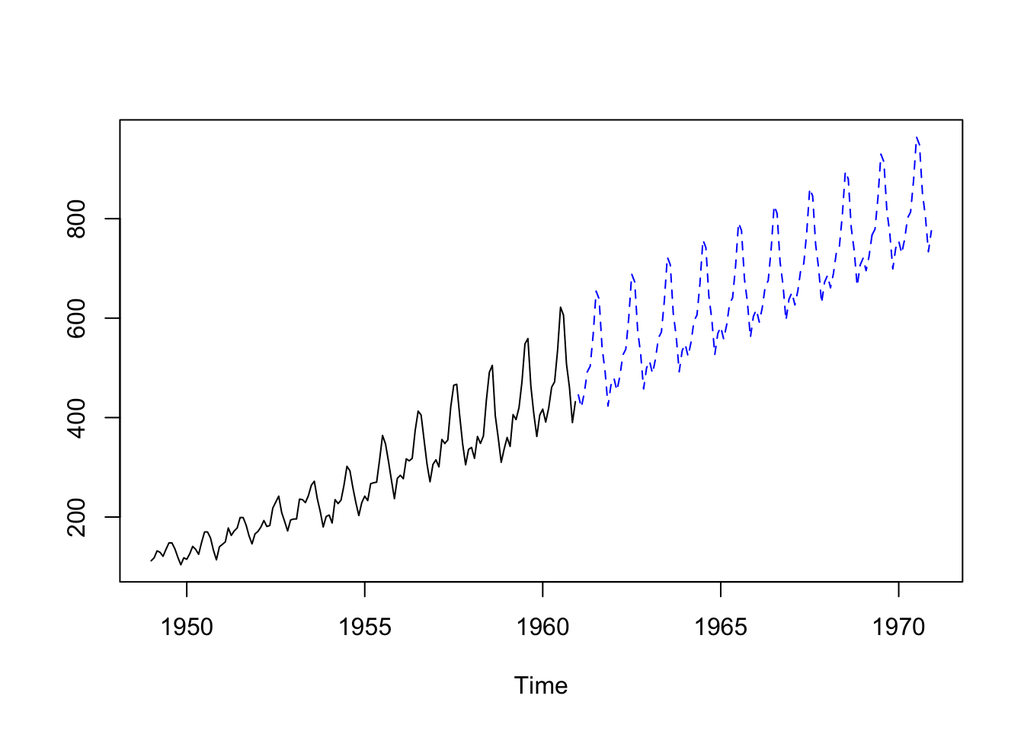

```r
ts.plot(AirPassengers, arima_forecast$mean, lty=c(1,2), col=c('black', "blue"))
```

## Summary

1. 지수이동평균법(Exponential Moving Avg)
- 모델링: Holtwinters (alpha, beta, gamma)
- alpha => 가장 직전 데이터의 가중치
- 나머지 모든 과거값은 0.8의 가중치를 나눠가짐.
- alpha를 정하지 않으면 자동으로 산출
- 예측: forecast()
- 지수이동평균법은 트렌드와 계절성을 고려하지 않으므로 2개이상을 예측하더라도 같은 예측치가 반복.
- 지수이동평균법은 바로 직후, 하나의 데이터의 미래를 예측할 때 예측할경우 많이 사용된다.
- 먼 미래, 여러 데이터의 예측을 할 경우 분해법, ARIMA가 사용된다.
2. 시계열분해법(HoltWinters, STL)
- 시계열을 Trend/Seasonal로 분해하여 각각을 예측하여 결합을통해 예측
- 원시계열을 트렌드, 계절성, 나머지 리마인더로 나눠서 보여준다.
- holtwinters(), hw(), stl() 사용.
3. ARIMA모형
- 시계열을 차분하여 정상성을 가지게한 다음, 자기상관(AR)변수 및 백색잡음변수(MA)를 사용하여 시계열을 설명할 수 있는 모델을 산출한다.
- AR(p) + MA(p) + differencing(d) = ARIMA(AR Intergated MA)
- auto.arima() 함수를 사용한다.
- 시계열에 x변수가 있는 경우가 있다.
- x변수(covariates)가 없을때: auto.arima(data) / 예측: forecast(arima, h=value)
- x변수룰 사용할 때: auto.arima(data, xreg=x변수) / 예측: forecast(arima, xreg)
4. 예측모형의 성능: Cross Validation for Forecasting(시계열예측): 데이터를 학습(모델링) 데이터와 테스트 데이터로 나눠서, 모델을 만들 때 학습데이터만을 사용하고 테스트 데이터를 통해 만들어진 모델을 검증하는 방법. 하나의 케이스로는 부족하기 때문에 전체 데이터를 학습/테스트 데이터로 랜덤하게 뽑아서 반복진행.
- 데이터에서 정해진 크기의 test-set를 추출
- Test set이전 데이터를 training set으로 정하고 예측모델링 진행
- 예측결과를 Test set과 비교
- 1, 2, 3을 다른 시간대별로 수행
- 시계열 예측에서는 시간데이터이기 떄문에 랜덤으로 데이터를 뽑는 것이 불가. 따라서 일정 시점까지의 데이터중 앞쪽 데이터를 학습, 뒷 부분을 테스트로 결정해 사용. 그 이후에 시점을 뒤로 늘려가며 학습/테스트를 반복 진행.
5. 예측모형의 성능: 모형성능 및 예측정확도 측정
- MSE = $1/n \Sigma(y_i - \hat{y_i})^2$
- MSE가 낮은 모형이 설명력이 높음(fitting)
- MAPE = $1/n \Sigma|y_i - \hat{y_i}| / y_i$
- MAPE가 낮은 모형이 정확도가 우수하다(forecasting)
- 분모: 실측치
- 분자: 실측치와 예측치의 차이
- 정확도 = 1 - MAPE (mean(100 - 100 * abs((“실제값”-“예측값”)/“실제값”)))
6. Coding

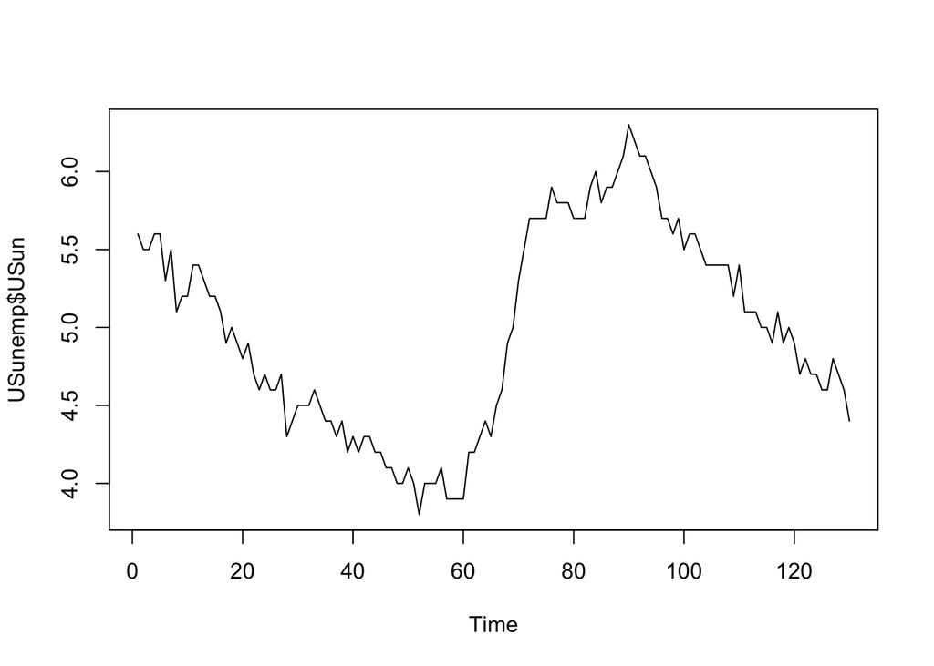

```r
# ARIMA 예측모델링

library(forecast)
library(tseries)

# Read Data
USunemp <- read.csv('./data/USunemp.csv')
ts.plot(USunemp$USun) #시계열 데이터가 아니더라도 시계열 그래프를 그릴 수 있음.
```

```r
dim(USunemp)
```

```
## [1] 130   1
```

```r
# Modeling set & Test set for forecasting 12 months ahead
# Using Cross Validation

# Modeling 1
ms_1 <- USunemp$USun[1:118]
ts_1 <- USunemp$USun[119:130]
# Modeling 2
ms_2 <- USunemp$USun[1:106]
ts_2 <- USunemp$USun[107:118]
# Modeling 3
ms_3 <- USunemp$USun[1:94]
ts_3 <- USunemp$USun[95:106]
# Transform modeling set to TS Object in R
ms_1 <- ts(ms_1, frequency=12)
ms_2 <- ts(ms_2, frequency=12)
ms_3 <- ts(ms_3, frequency=12)
#######################
# 1-Holt-Winters Method
#######################
hw_1 <- hw(ms_1)
hw_2 <- hw(ms_2)
hw_3 <- hw(ms_3)

hw_1_fcst <- forecast(hw_1, h=12)
hw_2_fcst <- forecast(hw_2, h=12)
hw_3_fcst <- forecast(hw_3, h=12)

attributes(hw_1_fcst)
```

```
## $names
##  [1] "model"     "mean"      "level"     "x"         "upper"
##  [6] "lower"     "fitted"    "method"    "series"    "residuals"
##
## $class
## [1] "forecast"
```

```r
cbind(forecast_value=hw_1_fcst$mean, test1_data=ts_1)
```

```
##        forecast_value test1_data
## Nov 10       4.932894        5.0
## Dec 10       4.897577        4.9
## Jan 11       4.807001        4.7
## Feb 11       4.810525        4.8
## Mar 11       4.741697        4.7
## Apr 11       4.699641        4.7
## May 11       4.663902        4.6
## Jun 11       4.678196        4.6
## Jul 11       4.663607        4.8
## Aug 11       4.561074        4.7
## Sep 11       4.581335        4.6
## Oct 11       4.502478        4.4
```

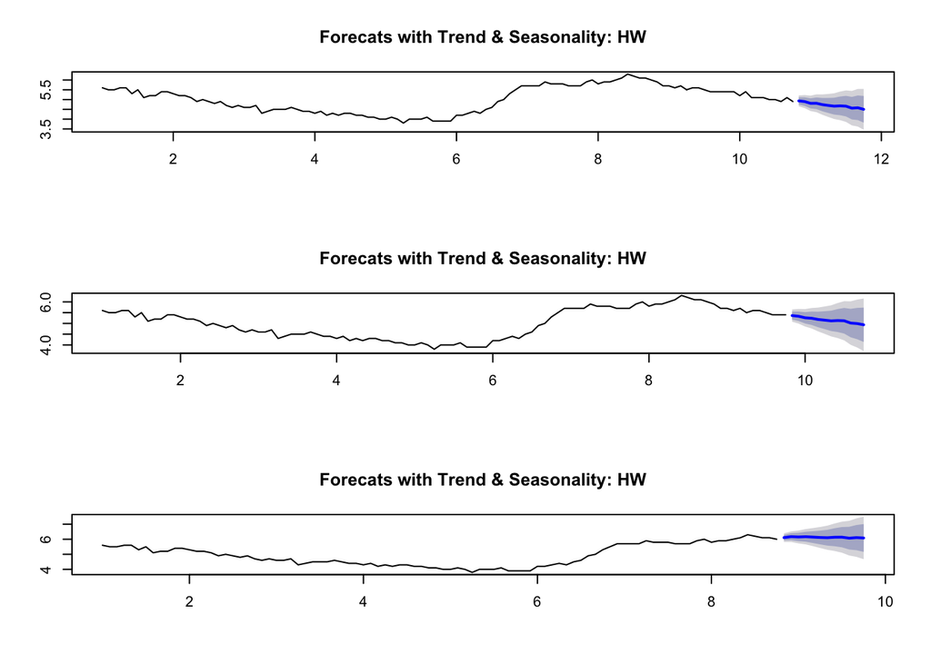

```r
par(mfrow=c(3,1))
plot(hw_1_fcst, main="Forecats with Trend & Seasonality: HW")
plot(hw_2_fcst, main="Forecats with Trend & Seasonality: HW")
plot(hw_3_fcst, main="Forecats with Trend & Seasonality: HW")
```

```r
# 1 - MAPE: 예측치가 시기에 따라 달라진다. CVT 장점.
100 - 100 * mean(abs(hw_1_fcst$mean-ts_1)/ts_1)
```

```
## [1] 98.63304
```

```r
100 - 100 * mean(abs(hw_2_fcst$mean-ts_2)/ts_2)
```

```
## [1] 98.38409
```

```r
100 - 100 * mean(abs(hw_3_fcst$mean-ts_3)/ts_3)
```

```
## [1] 90.25773
```

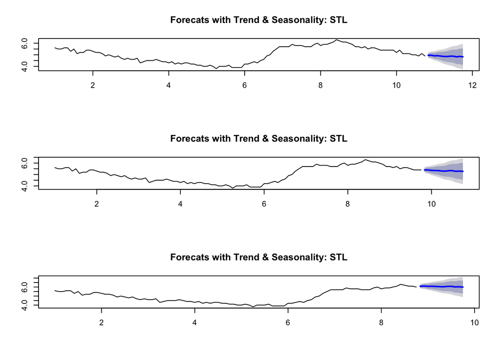

```r
#######
# 2-STL
#######
stl_1 <- stl(ms_1, s.window = 'per')
stl_2 <- stl(ms_2, s.window = 'per')
stl_3 <- stl(ms_3, s.window = 'per')

stl_1_fcst <- forecast(stl_1, h=12)
stl_2_fcst <- forecast(stl_2, h=12)
stl_3_fcst <- forecast(stl_3, h=12)

par(mfrow=c(3,1))
plot(stl_1_fcst, main="Forecats with Trend & Seasonality: STL")
plot(stl_2_fcst, main="Forecats with Trend & Seasonality: STL")
plot(stl_3_fcst, main="Forecats with Trend & Seasonality: STL")
```

```r
# 1 - MAPE: 예측치가 시기에 따라 달라진다. CVT 장점.
100 - 100 * mean(abs(stl_1_fcst$mean-ts_1)/ts_1)
```

```
## [1] 96.05077
```

```r
100 - 100 * mean(abs(stl_2_fcst$mean-ts_2)/ts_2)
```

```
## [1] 95.89188
```

```r
100 - 100 * mean(abs(stl_3_fcst$mean-ts_3)/ts_3)
```

```
## [1] 91.44237
```

```r
#########
# 3-ARIMA
#########

arima_1 <- auto.arima(ms_1)
arima_2 <- auto.arima(ms_2)
arima_3 <- auto.arima(ms_3)

arima_1_fcst <- forecast(arima_1, h = 12)
arima_2_fcst <- forecast(arima_2, h = 12)
arima_3_fcst <- forecast(arima_3, h = 12)

attributes(arima_1_fcst)
```

```
## $names
##  [1] "method"    "model"     "level"     "mean"      "lower"
##  [6] "upper"     "x"         "series"    "fitted"    "residuals"
##
## $class
## [1] "forecast"
```

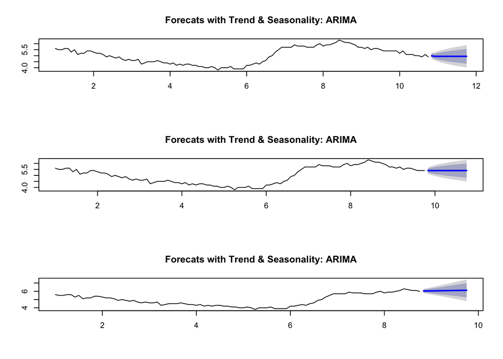

```r
plot(arima_1_fcst,main="Forecats with Trend & Seasonality: ARIMA")
plot(arima_2_fcst,main="Forecats with Trend & Seasonality: ARIMA")
plot(arima_3_fcst,main="Forecats with Trend & Seasonality: ARIMA")
```

```r
100 - 100 * mean(abs(arima_1_fcst$mean-ts_1)/ts_1);
```

```
## [1] 94.71676
```

```r
100 - 100 * mean(abs(arima_2_fcst$mean-ts_2)/ts_2);
```

```
## [1] 94.68469
```

```r
100 - 100 * mean(abs(arima_3_fcst$mean-ts_3)/ts_2)
```

```
## [1] 90.29132
```